# Unsere Hainleite

Man geht durch den Wald und merkt: es tut sich was. Kahle Fächen, ehemalige Waldhütten sind jetzt auf dem Felde. Wie viel Hainleite haben wir eigentlich schon verloren?

Diese Seite liefert Antworten darauf. Mit Hilfe von Satelliten-gestützten Rechenverfahren von Global Forest Watch zeigen wir klar und deutlich, dass es höchste Zeit ist, etwas zu tun.

## Verlorene Hektar Wald pro Jahr

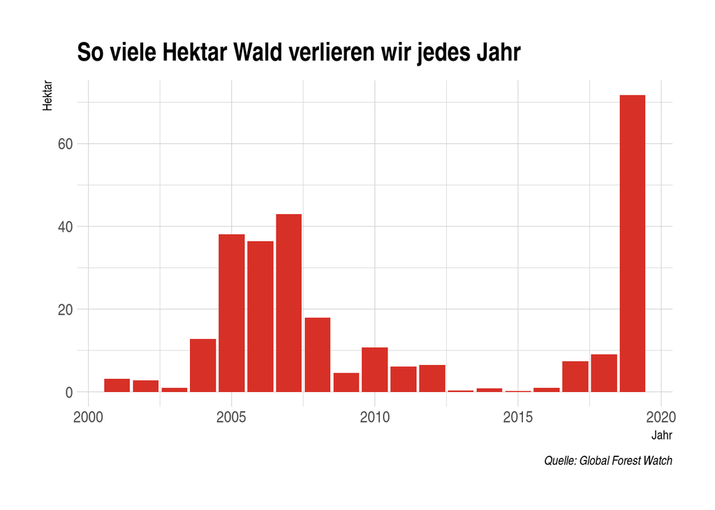

Zum Vergleich: von 2000 bis 2019 sind so viele Hektar Bäume dazgekommen. Das ist etwa ein Zehntel des Verlusts.

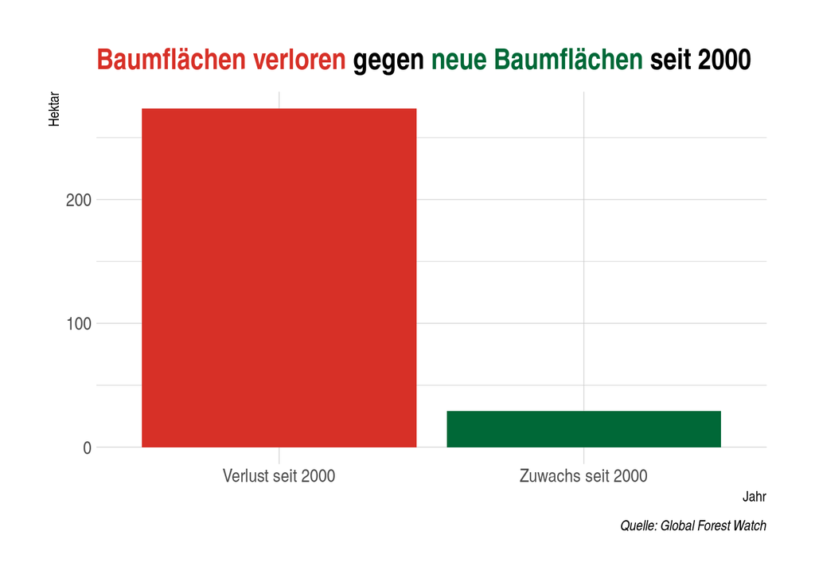

## Wo genau verlieren wir die Hainleite?

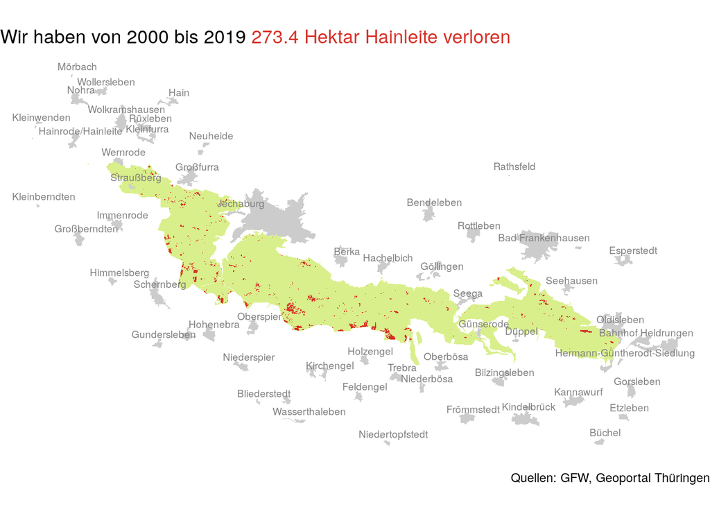

Vielleicht kannst du dir 273 Hektar Wald schwer vorstellen. Wir auch kaum. Also haben wir hier ein paar Vergleiche herausgesucht. 273 Hektar Wald sind so viel wie die **Siedlungsfläche von Oldisleben, Kindelbrück und Bendeleben zusammen:**

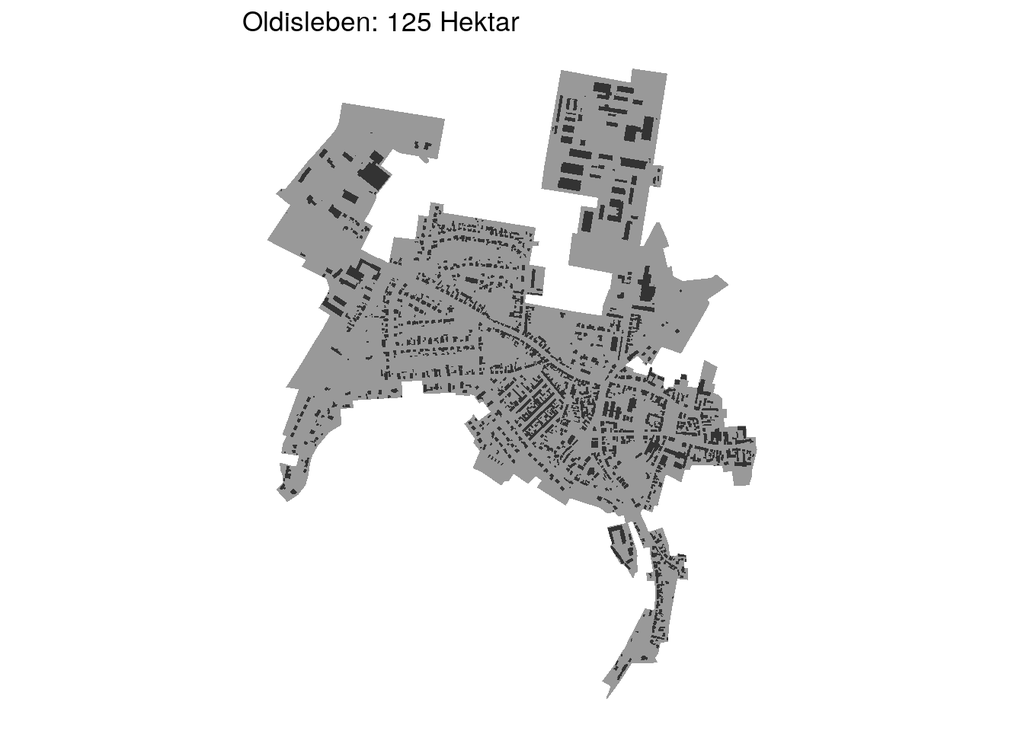

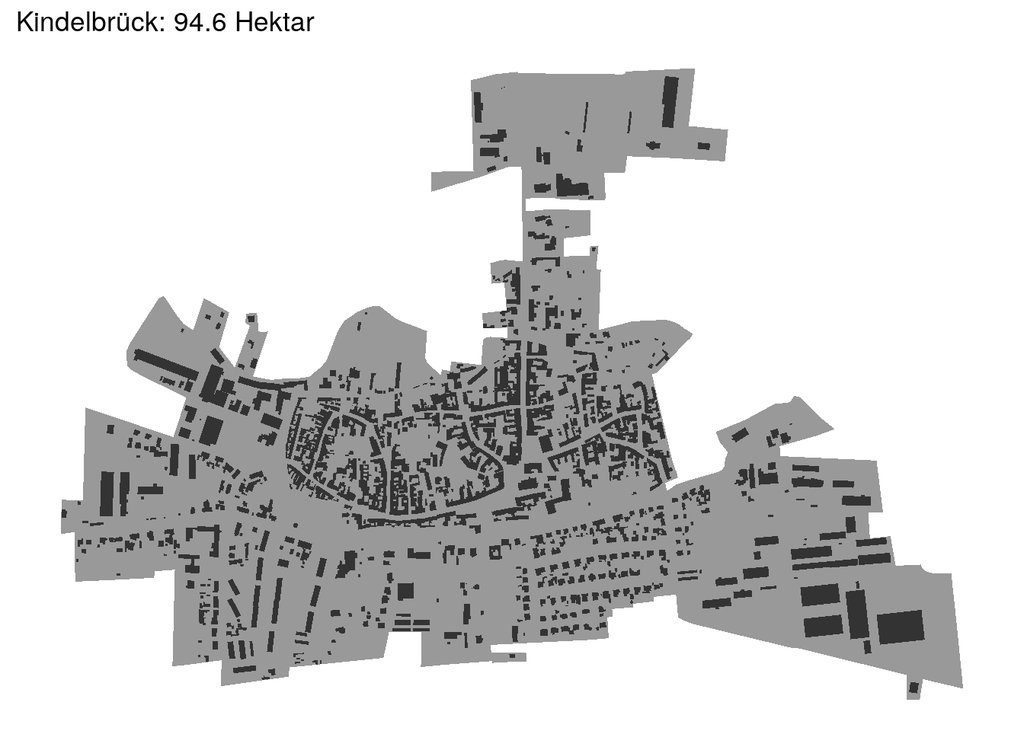

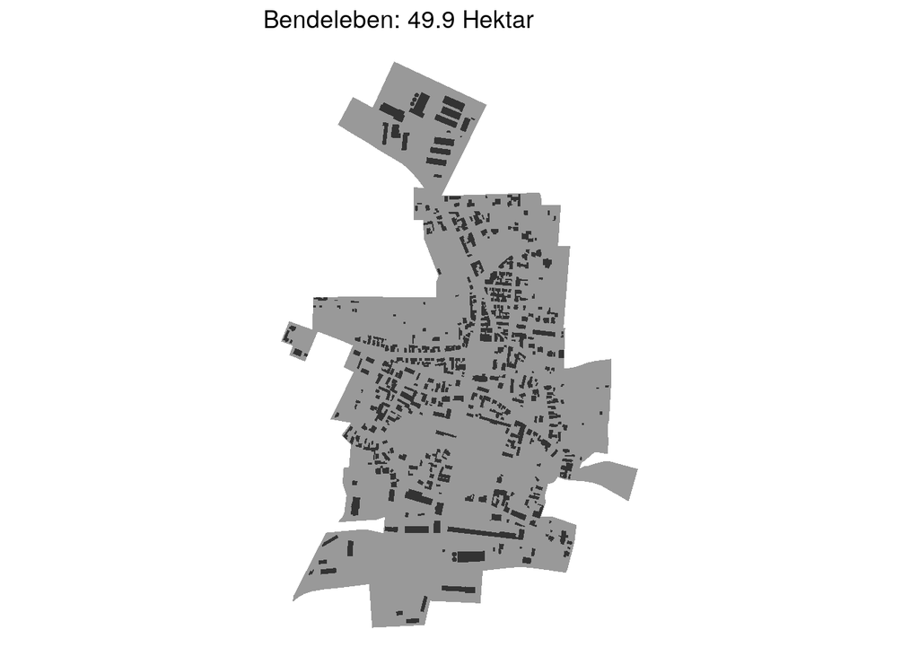

Das fatale Jahr 2019 nehmen wir noch einmal genauer in den Blick:

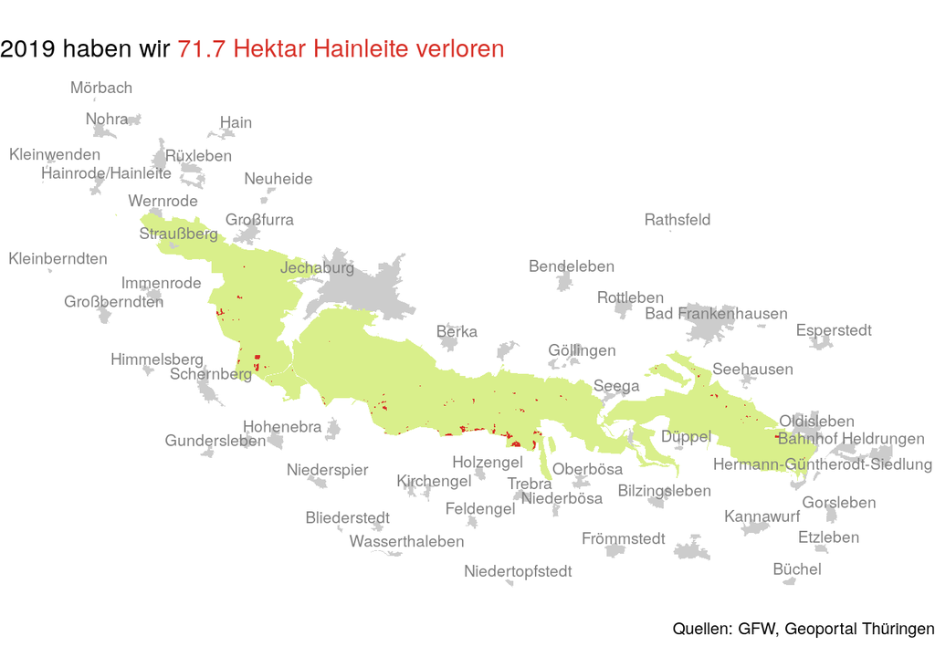

Zum Vergleich: alle roten Flächen zusammen sind etwa so groß wie Schernberg. Wir haben 2019 also so viele Hektar Bäume verloren, wie Schernberg groß ist.

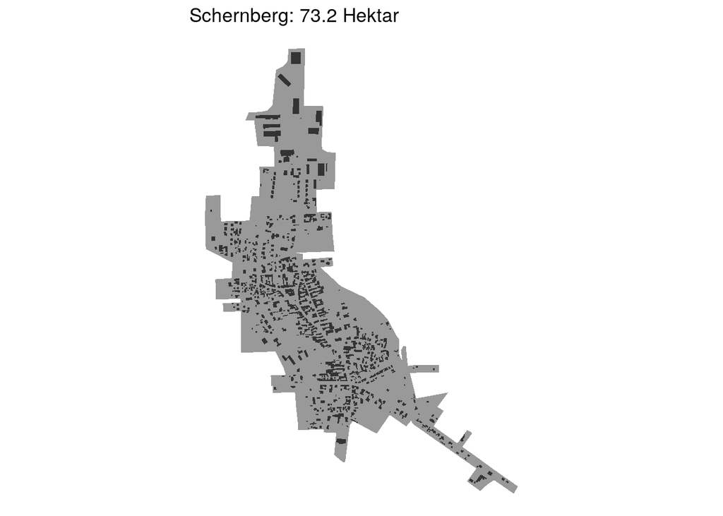

## Entdecke wie der Wald vor deiner Haustür verschwindet

Mit dieser interaktiven Karte kannst du hineinzoomen und schauen, wie Waldfächen in deiner Gegend verschwunden sind. Oder schau einfach in den Wald hinein.

[interactive chart not shown]

## FAQ

### Wer steckt dahinter?

[Christoph](https://chris.toph.eu), freiberuflicher Datenanalyst aus der Region.

### Woher stammen die Daten?

- Die Wald-Daten kommen von Global Forest Watch und können [hier](https://www.globalforestwatch.org/map/) eingesehen und [hier](https://data.globalforestwatch.org/datasets/14228e6347c44f5691572169e9e107ad) heruntergeladen werden.
- Die Größen von Siedlungen kommen vom [Geoportal Thüringen](https://www.geoportal-th.de/de-de/Downloadbereiche/Download-Offene-Geodaten-Th%C3%BCringen)

### Wie kann ich das selbst machen?

Der Quellcode ist [hier auf Github veröffentlicht](https://github.com/chris-toph-t/waldsterben).